# Exploratory Data Analysis

- Show All Code
- Hide All Code
- View Source

Author

Th. Senegas

Published

May 26, 2025

Below you will find an EDA of the data provided.

# 1. Loading Packages and Data

```r
# Load required libraries
library(tidyverse)
library(skimr)
library(lubridate)
library(purrr)
library(ggplot2)
library(scales)
library(highcharter)
library(naniar)

# Read csv files
products    <- read_csv("./data/products.csv") |>
    glimpse()
```

```
Rows: 3
Columns: 5
$ SKU              <chr> "Alpha", "Beta", "Gamma"
$ `Product Class`  <chr> "A", "A", "B"
$ `Product Family` <chr> "X1-G3", "X1-G3", "X1-S7"
$ `MSRP ($)`       <dbl> 99.99, 79.99, 39.99
$ `Margin (%)`     <dbl> 35, 20, 40
```

```r
locations   <- read_csv("./data/locations.csv") |>
    glimpse()
```

```
Rows: 10
Columns: 4
$ `Location ID`  <chr> "0001", "0002", "0003", "0004", "0005", "0006", "0007",…
$ Province       <chr> "QC", "QC", "QC", "QC", "QC", "QC", "QC", "QC", "QC", "…
$ `Region Type`  <chr> "Urban", "Urban", "Semi-Urban", "Rural", "Urban", "Urba…
$ `Surface Area` <dbl> 30000, NA, 50000, 40000, 40000, 30000, 35000, 35000, NA…
```

```r
transactions<- read_csv("./data/transactions.csv") |>
    glimpse()
```

```
Rows: 7,951
Columns: 6
$ `Transaction ID` <chr> "9c42d970-ad54-47af-a151-8ba6955cc539", "3f8cdb5c-3cc…
$ Date             <date> 2021-02-01, 2021-02-01, 2021-02-02, 2021-02-02, 2021…
$ `Location ID`    <chr> "0008", "0001", "0009", "0009", "0007", "0007", "0001…
$ SKU              <chr> "Alpha", "Alpha", "Gamma", "Gamma", "Gamma", "Gamma",…
$ Quantity         <dbl> 2, 1, 1, 1, 1, 1, 1, 1, 1, 1, 1, 1, 1, 1, 1, 1, 1, 1,…
$ `Value ($)`      <dbl> 199.98, 99.99, 39.99, 39.99, 39.99, 39.99, 39.99, 39.…
```

# 2. Join the 3 csv files together and overview of the data

```r
df <- transactions |>
  # ensure Date is a Date
  mutate(Date = lubridate::ymd(Date)) |>
  left_join(products,    by = "SKU") |>
  left_join(locations,   by = "Location ID")

skim(df)
```

Data summary

| Name | df |
| --- | --- |
| Number of rows | 7951 |
| Number of columns | 13 |
| _______________________ |  |
| Column type frequency: |  |
| character | 7 |
| Date | 1 |
| numeric | 5 |
| ________________________ |  |
| Group variables | None |

**Variable type: character**

| skim_variable | n_missing | complete_rate | min | max | empty | n_unique | whitespace |
| --- | --- | --- | --- | --- | --- | --- | --- |
| Transaction ID | 0 | 1 | 36 | 36 | 0 | 7951 | 0 |
| Location ID | 0 | 1 | 4 | 4 | 0 | 10 | 0 |
| SKU | 0 | 1 | 4 | 5 | 0 | 3 | 0 |
| Product Class | 0 | 1 | 1 | 1 | 0 | 2 | 0 |
| Product Family | 0 | 1 | 5 | 5 | 0 | 2 | 0 |
| Province | 0 | 1 | 2 | 2 | 0 | 1 | 0 |
| Region Type | 0 | 1 | 5 | 10 | 0 | 3 | 0 |

**Variable type: Date**

| skim_variable | n_missing | complete_rate | min | max | median | n_unique |
| --- | --- | --- | --- | --- | --- | --- |
| Date | 0 | 1 | 2021-02-01 | 2025-03-31 | 2023-02-21 | 1466 |

**Variable type: numeric**

[output not shown]

**What we learn:**

- 7,951 unique transactions accross 10 differents locations (store) for 3 differents products (SKU) divided into two product families (X1-G3 or X1-S7)
- Date range: 2021-02-01 → 2025-03-31
- SKU counts: Gamma 3 973, Alpha 3 094, Beta 884
- Quantity: mean 1.02, sd 1.49, min –1, max 132
- Value ($): mean 68.67, sd 151.12, min –99.99, max 13 198.68

# 3. Looking for missing data and anomalies

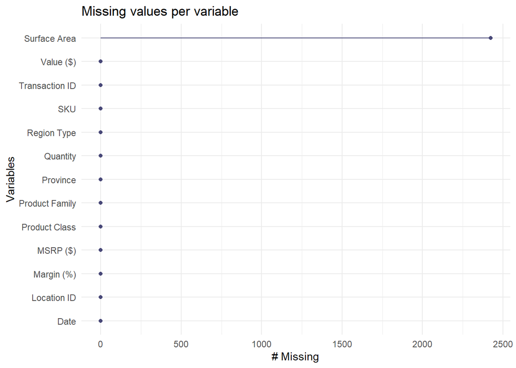

```r
# 3a) Missingness plot
gg_miss_var(df) +
     labs(title = "Missing values per variable")
```

```r
# 3b) Tabulate missing counts
df |>
 summarise_all(~ sum(is.na(.)))
```

```
# A tibble: 1 × 13
  `Transaction ID`  Date `Location ID`   SKU Quantity `Value ($)`
             <int> <int>         <int> <int>    <int>       <int>
1                0     0             0     0        0           0
# ℹ 7 more variables: `Product Class` <int>, `Product Family` <int>,
#   `MSRP ($)` <int>, `Margin (%)` <int>, Province <int>, `Region Type` <int>,
#   `Surface Area` <int>
```

```r
# 3c) Anomalies: negative quantities (likely returns)
returns <- df |>
 filter(Quantity < 0)

# 3d) How many returns?
n_returns <- nrow(returns)

# 3e) One-off very large orders?
large_orders <- df |>
 filter(Quantity > 10)
```

**What we find**

- Missing: Of the 10 different locations, surface information is missing for two of them. These two stores account for around 30% of all transactions (2,424 transactions out of a total of 7,951).
- Returns: 79 transactions with Quantity = –1 (and matching negative Value ($))
- Bulk orders: only 1 transaction with Quantity = 132; while 97.2% of transactions have a quantity of 1 and few of 2 or 3 excluding the 79 returns.

# 4. Monthly dataset

In view of the number of observations (transactions) available and the objective of producing a demand forecast for inventory management purposes, we will aggregate the data on a monthly basis in order to produce a monthly forecast. To do this, we’ll keep the few observations (79) that we assume are returns. However, after a little deep dive for the bulk orders, we will remove this observation from our dataset.

```r
df_monthly <- df |>
    # Remove bulk order
    subset(Quantity <= 10) |>
    # Create month index and unit price
    mutate(
        month = floor_date(as.Date(Date), unit = "month"),
        unit_price = `Value ($)` / Quantity
    ) |>
    group_by(month, `Location ID`, SKU, unit_price) |>
    mutate(
        quantity = sum(Quantity),
        sales_cad = sum(`Value ($)`)
    ) |>
    select(-`Transaction ID`) |>
    select(month, `Location ID`, SKU, quantity, unit_price, sales_cad, `Product Class`, `Product Family`, `MSRP ($)`, `Margin (%)`, `Region Type`, `Surface Area`) |>
    ungroup() |>
    unique()

write.csv(df_monthly, './data/df_monthly.csv', row.names = F)
```

# 5. Plot for Describing and understand the data

## 5.1 Quantity Sold per month per store (all products combined)

```r
df_hc_qty <- df_monthly |>
    group_by(month, `Location ID`) |>
    mutate(
        quantity = sum(quantity)
    ) |>
    ungroup() |>
    select(month, `Location ID`, quantity) |>
    unique() |>
    mutate(month_ts = datetime_to_timestamp(month))

hc_loc <- highchart(type = "stock") |>
  hc_title(text = "Monthly Quantity by Location") |>
  hc_xAxis(type = "datetime")

for(loc in unique(df_hc_qty$`Location ID`)) {
  tmp <- df_hc_qty |>
   filter(`Location ID` == loc)
  hc_loc <- hc_loc |>
    hc_add_series(
      data = list_parse2(tibble(x = tmp$month_ts, y = tmp$quantity)),
      name = loc,
      type = "line"
    )
}

hc_loc |>
  hc_legend(enabled = TRUE, align = "center", layout = "horizontal", verticalAlign = "bottom")
```

[interactive chart not shown]

## 5.2 Quantity Sold per month per Region type (all products combined)

```r
df_hc_qty <- df_monthly |>
    group_by(month, `Region Type`) |>
    mutate(
        quantity = sum(quantity)
    ) |>
    ungroup() |>
    select(month, `Region Type`, quantity) |>
    unique() |>
    mutate(month_ts = datetime_to_timestamp(month))

hc_loc <- highchart(type = "stock") |>
  hc_title(text = "Monthly Quantity by Region Type") |>
  hc_xAxis(type = "datetime")

for(loc in unique(df_hc_qty$`Region Type`)) {
  tmp <- df_hc_qty |>
   filter(`Region Type` == loc)
  hc_loc <- hc_loc |>
    hc_add_series(
      data = list_parse2(tibble(x = tmp$month_ts, y = tmp$quantity)),
      name = loc,
      type = "line"
    )
}

hc_loc |>
  hc_legend(enabled = TRUE, align = "center", layout = "horizontal", verticalAlign = "bottom")
```

[interactive chart not shown]

## 5.3 Quantity Sold per month per Surface area (all products combined)

```r
df_hc_qty <- df_monthly |>
    group_by(month, `Surface Area`) |>
    mutate(
        quantity = sum(quantity)
    ) |>
    ungroup() |>
    select(month, `Surface Area`, quantity) |>
    unique() |>
    mutate(month_ts = datetime_to_timestamp(month))

hc_loc <- highchart(type = "stock") |>
  hc_title(text = "Monthly Quantity by locations' surface area") |>
  hc_xAxis(type = "datetime")

for(loc in unique(df_hc_qty$`Surface Area`)) {
  tmp <- df_hc_qty |>
   filter(`Surface Area` == loc)
  hc_loc <- hc_loc |>
    hc_add_series(
      data = list_parse2(tibble(x = tmp$month_ts, y = tmp$quantity)),
      name = loc,
      type = "line"
    )
}

hc_loc |>
  hc_legend(enabled = TRUE, align = "center", layout = "horizontal", verticalAlign = "bottom")
```

[interactive chart not shown]

## 5.3 Quantity Sold per month per Product Family

```r
df_hc_qty <- df_monthly |>
    group_by(month, `Product Family`) |>
    mutate(
        quantity = sum(quantity)
    ) |>
    ungroup() |>
    select(month, `Product Family`, quantity) |>
    unique() |>
    mutate(month_ts = datetime_to_timestamp(month))

hc_loc <- highchart(type = "stock") |>
  hc_title(text = "Monthly Quantity by Product Family") |>
  hc_xAxis(type = "datetime")

for(loc in unique(df_hc_qty$`Product Family`)) {
  tmp <- df_hc_qty |>
   filter(`Product Family` == loc)
  hc_loc <- hc_loc |>
    hc_add_series(
      data = list_parse2(tibble(x = tmp$month_ts, y = tmp$quantity)),
      name = loc,
      type = "line"
    )
}

hc_loc |>
  hc_legend(enabled = TRUE, align = "center", layout = "horizontal", verticalAlign = "bottom")
```

[interactive chart not shown]

## 5.4 Promotion/Bundling effects on quantity sold

```r
# 1. Aggregate at month × SKU
df_sku <- df_monthly %>%
  group_by(month, SKU) %>%
  summarise(
    quantity  = sum(quantity),
    avg_price = weighted.mean(unit_price),
    .groups = "drop"
  )

# 2. Compute metrics per SKU
results <- df_sku %>%
  split(.$SKU) %>%
  map_dfr(function(dat){
    # correlation test
    ct   <- cor.test(dat$avg_price, dat$quantity)
    # linear regression
    lm1  <- lm(quantity ~ avg_price, data = dat)
    # log‐log regression (only positive obs)
    dat_pos <- filter(dat, quantity > 0, avg_price > 0)
    elast <- if(nrow(dat_pos) > 1) {
      coef(lm(log(quantity) ~ log(avg_price), data = dat_pos))["log(avg_price)"]
    } else {
      NA_real_
    }
    # assemble
    tibble(
      SKU           = dat$SKU[1],
      Pearson_r     = as.numeric(ct$estimate),
      p_value       = ct$p.value,
      Linear_slope  = coef(lm1)["avg_price"],
      Elasticity    = elast
    )
  })

# 3. Inspect
print(results)
```

```
# A tibble: 3 × 5
  SKU   Pearson_r p_value Linear_slope Elasticity
  <chr>     <dbl>   <dbl>        <dbl>      <dbl>
1 Alpha     0.253  0.107         2.61       3.04
2 Beta      0.133  0.358         0.265      0.833
3 Gamma     0.240  0.0933        1.78       0.828
```

Here’s the summary of how unit price relates to quantity for each SKU:

I concluded that none of the SKUs exhibit a clear inverse price–quantity relationship; instead, I observed modest positive correlations, which I believe are driven by promotions, bundling, or other confounding factors rather than true demand elasticity.

# 6. Key Takeaways from EDA

- **Strong, consistent seasonality**

All series (by SKU, location, region, family) show a clear yearly peak in Nov-Dec and a trough in Jan–Feb.

- **SKU × Location heterogeneity**

Some locations consistently sell much more than others, even after accounting for size (surface area). Within a location, different SKUs have distinct volume profiles.

- **Weak price sensitivity**

Across and within SKUs, price–quantity correlations were small (and in fact slightly positive), suggesting that price changes mainly reflect promotions or bundling rather than pure demand shifts.

- **Few true “outliers” or stock-out signals**

Returns and bulk orders are rare (<2 % of transactions), so most monthly dips aren’t driven by extreme events.